# Complementary analysis

J. Ignacio Lucas Lledó

25/11/2020

## Introduction

In the current version of the manuscript, the relationship between gut microbiota composition and life history traits is explored with only a redundancy analysis with a particular choice of candidate ASVs. The results are suggestive, but probably not very robust to alternative choices of FDR and skewness thresholds, among other more or less arbitrary choices (for example, the logarithmic transformation of relative ASV abundances). Readers would probably thank an alternative approach, at least to be convinced that a relationship exists between microbiota composition and male life history traits. And the fact is that we did run a different analysis before the RDA, which was based on a PCA of life history traits and a rotated MDS of microbiota composition. Those were actually the results reported by Zahida in her dissertation, and the main reason to exclude them from the manuscript was to simplify the exposition of methods and results.

Here, I want to replicate the PCA and associated analyses, as well as compensate the excessive attention given to ASVs.

## Import data

```r
load('../2020-04-22/Diversity.RData')
```

The file `.../2020-04-22/Diversity.RData` includes 16 objects, of which:

- **Ar** is the matrix of abundance data (in absolute counts) of 2659 ASVs (columns) in 177 samples.
- **Ar.prop** is the corresponding matrix of relative abundances (relative to each sample total).
- **SampleData** is a data frame with age, isoline, replicate and sequencing run of every sample.
- **Traits** is a data frame with taxonomy and abundance information on all 2659 ASVs.

The rest can be ignored.

```r
rm(list=ls()[! ls() %in% c('Ar','Ar.prop','SampleData','Traits')])
```

Life history traits are stored in `../../data/LifeHistoryVar.txt`.

```r
LH <- read.table('../../data/LifeHistoryVar.txt', header=TRUE, row.names=1)
LH$CSrel <- LH$CSSlope / LH$CSearly
```

The `LH` data frame includes variables that will not be used and a couple of isolines without microbiome data. Before cleaning it up, however, I run the multiple imputations, in order to use all of the available information when imputing.

```r
library(mice)  # for imputation
# Centering. Using "apply()" instead would produce a matrix.
LH.centered <- as.data.frame(lapply(LH, function(x) (x - mean(x, na.rm=TRUE)) / sd(x, na.rm=TRUE)))
row.names(LH.centered) <- row.names(LH)
LH.imputation <- mice(LH.centered, m = 10, seed = 108, printFlag = FALSE)
LH.imputed <- complete(LH.imputation, action = 'all')
validIsolines  <- levels(SampleData$isoline)
validVariables <- c('AvLF','CSearly', 'CSSlope', 'EarlyRS', 'Rsen', 'ActuarialB')
LH.imputed <- lapply(LH.imputed, function(x, f1=validIsolines, f2=validVariables) x[f1, f2])
```

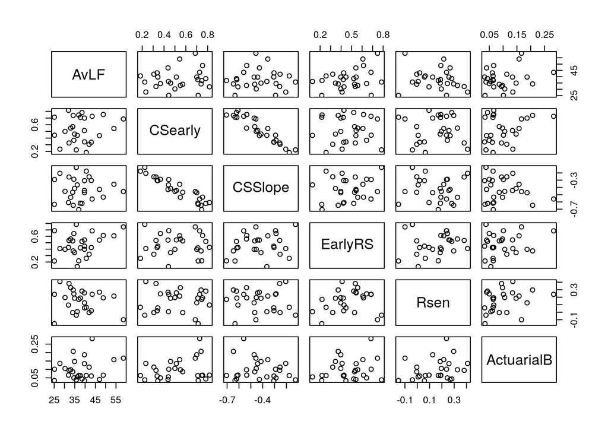

```r
LH.reduced <- LH[! is.na(LH$ActuarialB), validVariables]
pairs(LH.reduced)
```

## PCA of *reduced* life history traits

The *reduced* data set excludes the two isolines for which the actuarial ageing ($\beta$ parameter of the Gompertz fit) could not be estimated, namely 12, 36. There are, thus, 27 isolines in this matrix, and six life history variables:

- Two functional measures:
  - **Early climbing speed**: How quickly males climb vertically when young, a proxy for their anti-predatory performance and general flying/reaction speed.
  - **Functional ageing**: Climbing speed slope, or the slope of the regression climbing speed $\sim$ age. This is a measure of how steeply climbing speed decreases with age, so a measure of functional senescence.
- Reproductive fitness:
  - **Early reproductive fitness**: Relative success of young males when competing against other males for reproduction.
  - **Reproductive senescence**: The difference in reproductive fitness between young and old males of each isoline, which gives us a measure of reproductive ageing.
- Actuarial ageing:
  - **Average lifespan** of the isoline.
  - **Acceleration of mortality rate**: This is the beta component in a Gompertz fit on the survival curve of each isoline. It gives us a measure of how mortality accelerates with age in each isoline. In combination with lifespan, it pretty much describes actuarial ageing.

```r
LH.pca <- prcomp(LH.reduced, center = TRUE, scale. = TRUE)
summary(LH.pca)
```

```
## Importance of components:
##                           PC1    PC2    PC3    PC4     PC5     PC6
## Standard deviation     1.4319 1.2406 1.0958 0.8358 0.69086 0.18391
## Proportion of Variance 0.3417 0.2565 0.2001 0.1164 0.07955 0.00564
## Cumulative Proportion  0.3417 0.5982 0.7984 0.9148 0.99436 1.00000
```

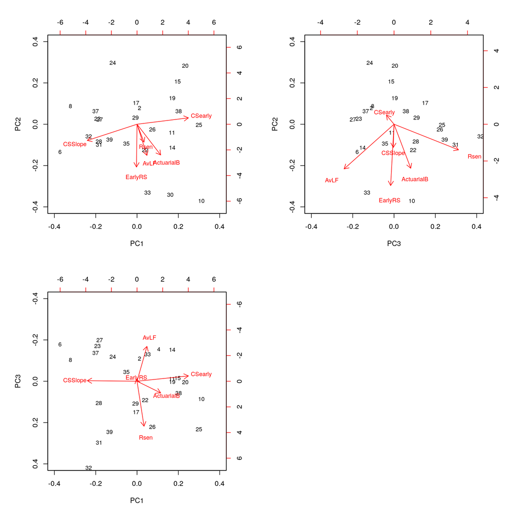

```r
par(mfrow=c(2,2))
biplot(LH.pca, choices = c(1,2), xlim = c(-0.4, 0.4), ylim = c(-0.4, 0.4))
biplot(LH.pca, choices = c(3,2), xlim = c(-0.4, 0.4), ylim = c(-0.4, 0.4))
biplot(LH.pca, choices = c(1,3), xlim = c(-0.4, 0.4), ylim = c(0.4, -0.4))
par(mfrow=c(1,1))
```

This analysis suggests PC1 is dominated by variation in climbing speed, which represents physical condition or performance. Note, however, that the two variables `CSearly` and `CSSlope` are negatively correlated due to their mathematical dependence: `CSSlope = CSlate - CSearly`. PC2 is mostly explained by early reproductive success (`EarlyRS`). And PC3 is mostly explained by reproductive senescence and life span, with positive values indicating faster reproductive senescence and shorter life span. The three principal components found have clear biological interpretations, under this selection of of life history variables.

I would like to consider an alternative selection of variables. Instead of `CSSlope`, I would choose `CSlate`, which is not mathematically dependent on `CSearly`. And I would log-transform `ActuarialB`, to correct its skewness and because I think it can make biological sense.

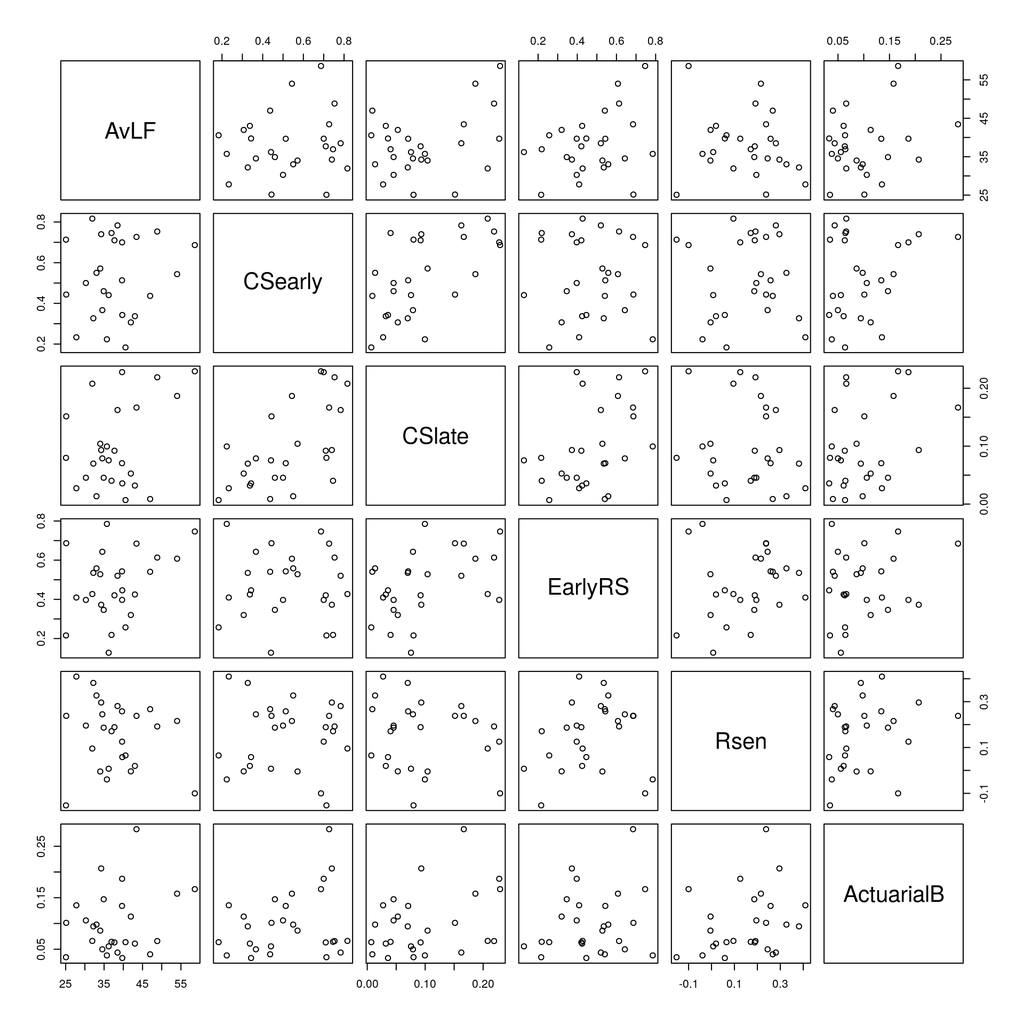

```r
LH.reduced2 <- LH[! is.na(LH$ActuarialB),
                  c('AvLF','CSearly', 'CSlate', 'EarlyRS', 'Rsen', 'ActuarialB')]
pairs(LH.reduced2)
```

```r
LH.reduced2$ActuarialB <- log(LH.reduced2$ActuarialB)
LH.pca2 <- prcomp(LH.reduced2, center = TRUE, scale. = TRUE)
summary(LH.pca2)
```

```
## Importance of components:
##                           PC1    PC2    PC3    PC4    PC5     PC6
## Standard deviation     1.4690 1.1512 1.0435 0.8624 0.7091 0.42578
## Proportion of Variance 0.3597 0.2209 0.1815 0.1240 0.0838 0.03022
## Cumulative Proportion  0.3597 0.5805 0.7620 0.8860 0.9698 1.00000
```

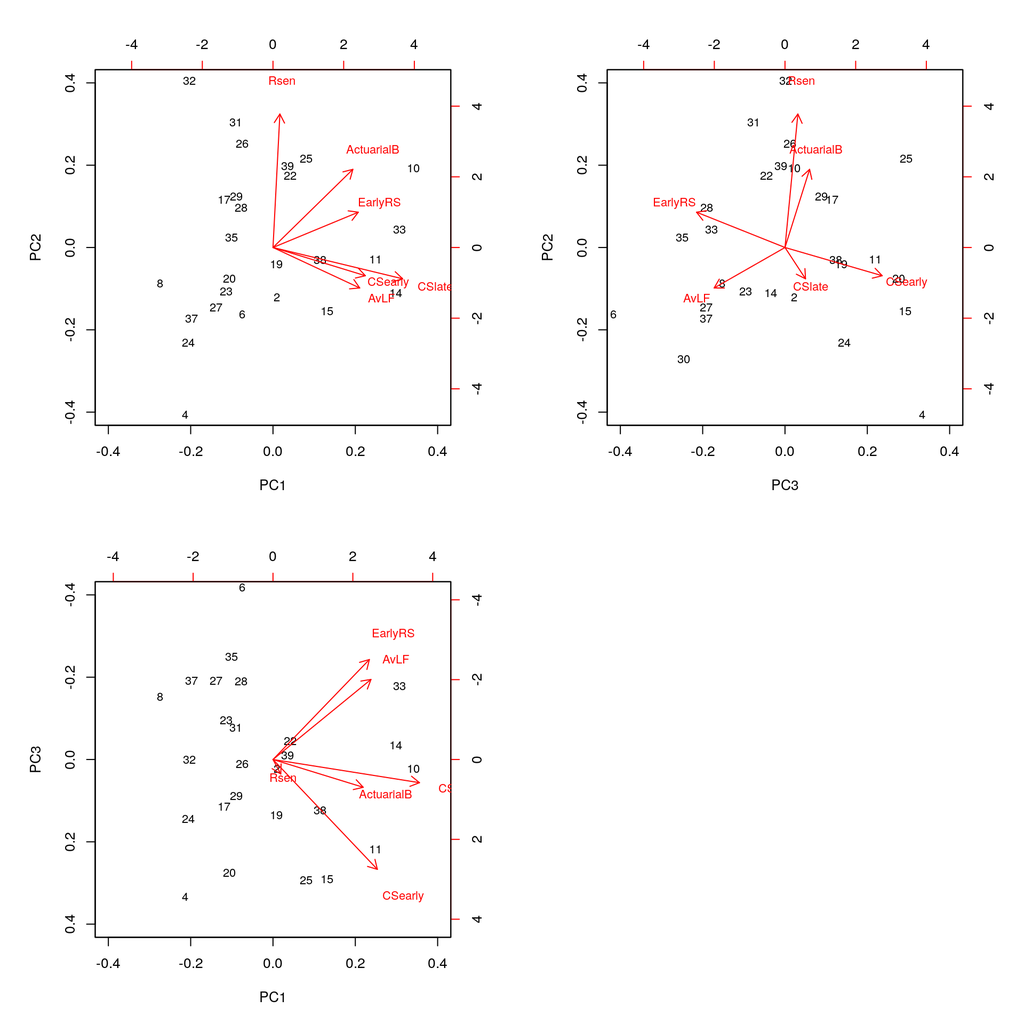

```r
par(mfrow=c(2,2))
biplot(LH.pca2, choices = c(1,2), xlim = c(-0.4, 0.4), ylim = c(-0.4, 0.4))
biplot(LH.pca2, choices = c(3,2), xlim = c(-0.4, 0.4), ylim = c(-0.4, 0.4))
biplot(LH.pca2, choices = c(1,3), xlim = c(-0.4, 0.4), ylim = c(0.4, -0.4))
par(mfrow=c(1,1))
```

The interpretation of these principal components is less straightforward. The fact that most variables increase towards positive values of PC1 (except for reproductive senescence), seems to reflect the fact that most variation in life history traits is due to genetic quality differences among isolines, rather than to evolved strategies. However, `ActuarialB` also loads positively on PC1, which contradicts the idea that positive PC1 simply means better overall performance.

## Summary of abundance data

On `2020-02-27` I used the `phyloseq` package to merge abundance, taxonomy and phylogenetic information in one object. After experiencing with some abundance and prevalence thresholds for filtering ASVs, and also after exploring different distance measures for ordination, I concluded that early and old samples differences in taxonomic composition were rather mild. In particular, I used the quite permissive minimum average proportion of $10^{-5}$. Also, the lack of familiarity with `phyloseq` makes me doubt the data was handled well. Most striking is the fact that presence-absence measures of composition distance among samples were the only ones that produced ordinations that clearly separated early from late samples.

Such a use of low-abundance ASVs and presence-absence measures of composition distance are very much at odds with the current understanding of the data set. According to our analysis in `2020-04-27`, not only phylogenetic information but also abundance should be included in the distance measures in order to appreciate a pattern that is both quite apparent at the genus level and very much reasonable: the loss of $\beta$ diversity with age.

Thus, instead of replicating the original characterization of microbiome composition from `2020-02-27`, I will start over. First, before filtering by abundance, I will generate the matrix of genus abundance.

### Genus abundance

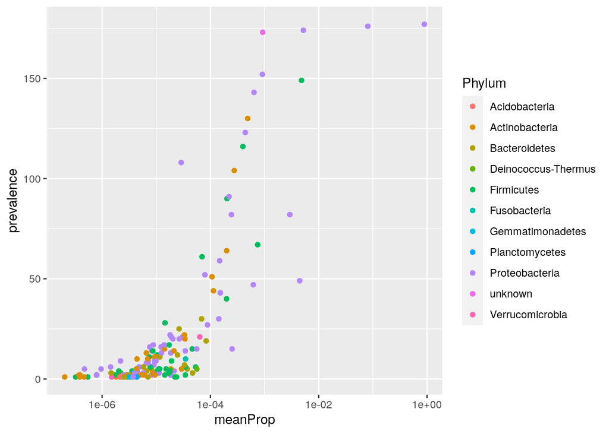

```r
library(ggplot2)
stopifnot(all.equal(rownames(Traits), colnames(Ar)))
Traits[is.na(Traits$Genus), 'Genus'] <- 'unknown'
# Having no NA values in Genus, I can use "==" below, instead of "%in%".
# Using sapply(..., simplify=FALSE) instead of lapply() I get columns named by genus
Genera.counts <- do.call(cbind,
                         sapply(unique(Traits$Genus),
                                function(x, G=Traits, M=Ar) {
                                  f <- rownames(G[G$Genus == x,])
                                  rowSums(M[, f, drop=FALSE])
                                },
                                simplify = FALSE))
# I generate genus frequencies by adding up ASV frequencies, instead of normalizing
# the counts in case ASV relative frequencies do not add up to 1, if some ASVs
# have already been filtered out.
Genera.prop <- do.call(cbind,
                       sapply(unique(Traits$Genus),
                              function(x, G=Traits, M=Ar.prop) {
                                f <- rownames(G[G$Genus == x,])
                                rowSums(M[, f, drop = FALSE])
                              },
                              simplify = FALSE))

Taxonomy <- unique(Traits[Traits$Genus != 'unknown', c('Genus','Family','Order','Class','Phylum')])
Taxonomy <- rbind(Taxonomy, rep('unknown', 5))
row.names(Taxonomy) <- Taxonomy$Genus

stopifnot(all.equal(row.names(SampleData), row.names(Genera.counts)))
stopifnot(all.equal(row.names(SampleData), row.names(Genera.prop)))
Genera.summary <- data.frame(prevalence = colSums(Genera.counts > 0),
                             meanProp   = colSums(Genera.prop) / dim(Genera.prop)[1],
                             EarlyPrev  = colSums(Genera.counts[SampleData$age == 'Early',] > 0),
                             LatePrev   = colSums(Genera.counts[SampleData$age == 'Late', ] > 0),
                             EarlyMeanProp = colSums(Genera.prop[SampleData$age == 'Early',]) /
                               sum(SampleData$age == 'Early'),
                             LateMeanProp  = colSums(Genera.prop[SampleData$age == 'Late', ]) /
                               sum(SampleData$age == 'Late'),
                             Family = Taxonomy[colnames(Genera.prop),'Family'],
                             Order =  Taxonomy[colnames(Genera.prop),'Order'],
                             Class =  Taxonomy[colnames(Genera.prop),'Class'],
                             Phylum = Taxonomy[colnames(Genera.prop),'Phylum'])
ggplot(data=Genera.summary, mapping=aes(x=meanProp, y=prevalence, color=Phylum)) +
  geom_point() + scale_x_log10()
```

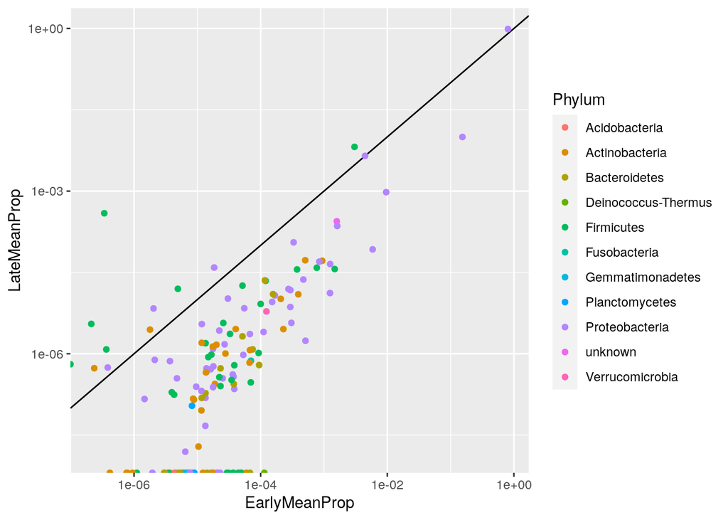

```r
ggplot() + geom_abline(slope=1, intercept=0) +
  geom_point(data=Genera.summary, mapping=aes(x=EarlyMeanProp, y=LateMeanProp, color=Phylum)) +
  scale_x_log10() + scale_y_log10()
```

### ASV abundance

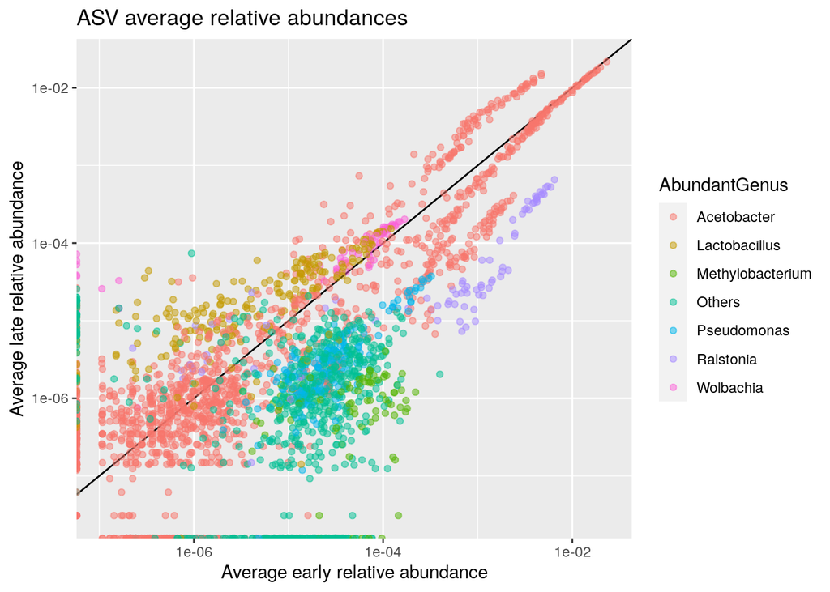

```r
Traits$AbundantGenus <- Traits$Genus
RareGenera <- unique(row.names(Genera.summary[Genera.summary$meanProp < 0.001,]))
Traits[Traits$Genus %in% RareGenera, 'AbundantGenus'] <- 'Others'
ggplot() + geom_abline(slope=1, intercept=0) +
  geom_point(data=Traits, mapping=aes(x=EA.meanProp, y=LA.meanProp, color=AbundantGenus), alpha=0.5) +
  scale_x_log10() + scale_y_log10() + xlab('Average early relative abundance') +
  ylab('Average late relative abundance') + ggtitle('ASV average relative abundances')
```

The plot above represents the relationship between early and late ASV average relative abundances, in logarithmic scale. The black line in the background corresponds to no change in average abundance between early and late samples. Amplicons below the black line reduced average relative abundance, and those above, increased it. The significance of the change cannot be assessed, because the biological variation of an amplicon’s abundance across replicates is not shown.

Color indicates the genus, if it is an abundant genus.

What is remarkable in that plot is that several ASVs of high average relative abundance cluster in lines of almost unit slope. Because it’s in logarithmic scale, those clusters respresent subsets of ASVs with an almost identical fold change of average relative abundances.

ASVs colored as “Others” correspond to several rare genera, most of which becoming even rarer with age. A similar behaviour is observed in *Methylobacterium*: while as a set, the genus is quite abundant, few of its ASVs ever reach a relative abundance of $10^{-4}$, and they all reduce their representation with age.

The figure reveals a problem with the taxonomic attribution: we lack resolution in the *Acetobacter* genus, where different subsets behave in consistent and different ways. They probably represent different lineages or species. Without being able to refer to those categories, the description of sample’ composition will be incomplete and therefore less likely to correlate with life history trait variation.

At least, the figure offers also some guidance to filtering by abundance.